# Visualisierung Linearer Regression

Auf dieser Seite findest du eine Einführung in die Visualisierung Linearer Regression.

Der gesamte Code, den du hier findest, kann von dir 1:1 in R umgesetzt werden. Die größte Lernwirkung hat diese Einführung, wenn du möglichst alles einmal selbst in R durchführst.

# 01 Vorbereitungen

Bevor wir loslegen können, müssen wir die Packages laden, die wir für unser Vorhaben benötigen. Falls du dieses noch nicht geladen hast, hole dies nun nach:

```r
library(SfL)
library(ggplot2)
```

Neu hinzu kommt das folgende Package:

```r
library(visreg)
```

Installiere das Package entweder mit untenstehendem Code oder über die Funktionen von RStudio.

```r
install.packages("visreg")
```

Nun laden wir die Datensätze, die wir nutzen werden:

```r
data(data_a)
data(data_c)
data(data_s)
data(data_t)
data(data_v)
```

Für die folgenden Demonstrationen erstellen wir zunächst ein Multiples Lineares Modell:

```r
lm <- lm(sDurLog ~ typeOfS + baseDurLog + pauseBin + bsex, data = data_s)
```

# 02 visreg

Wie wir bereits gelernt haben, gibt es in R eine Vielzahl an Möglichkeiten, Daten zu visualisieren. Ein praktisches Package zur Visualisierung von linearen Modellen ist das `visreg` Package.

Schauen wir uns die Hauptfunktion des Packages an. Wir nennen das Modell, das genutzt werden soll, sowie die Prediktorvariable, deren Effekt dargestellt werden soll.

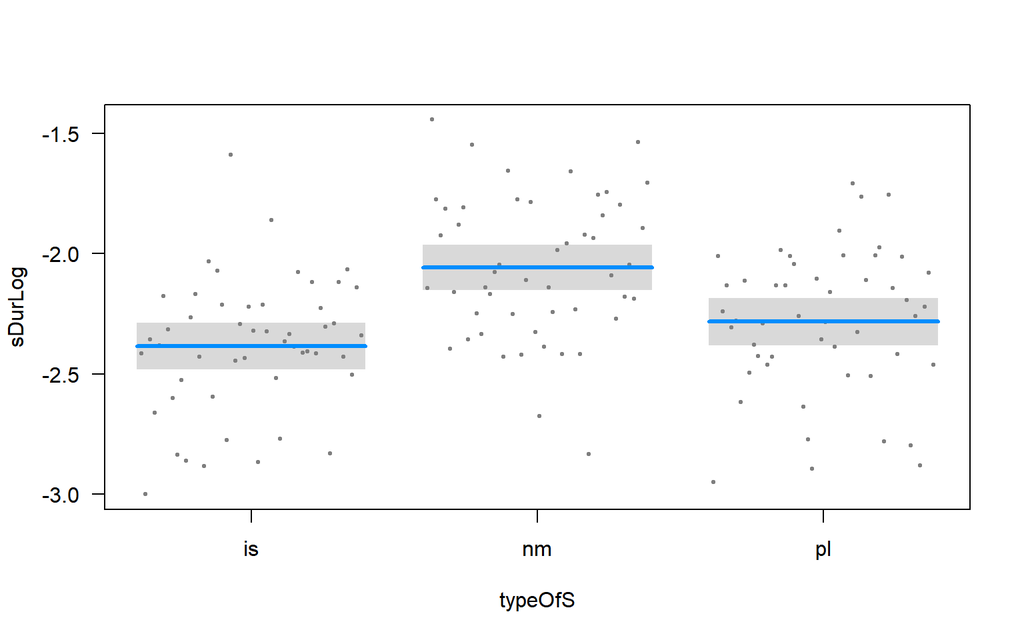

```r
visreg(lm, "typeOfS")
```

Abgebildet sehen wir also den Effekt von `typeOfS` mit den drei Levels auf der X-Achse und den vorhergesagten Werten von `sDurLog` auf der Y-Achse.

# 03 Transformation

Beim obigen Plot sticht ein Problem ins Auge: Kein Mensch kann log-transformierte Werte - wie hier auf der Y-Achse - sinnvoll interpretieren. Praktischerweise können wir diese direkt im Befehl zurück transformieren:

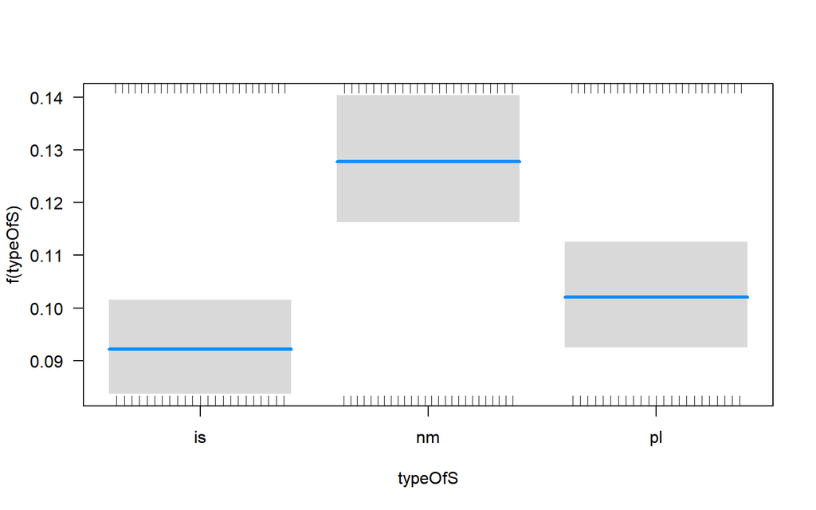

```r
visreg(lm, "typeOfS", trans = exp)
```

Hier werden auf der Y-Achse nun wieder interpretierbare Werte dargestellt.

# 04 Kontinuierliche Variablen

Bisher haben wir nur Plots für eine kategorische Variable gesehen. Schauen wir uns daher nun die Darstellung von `baseDurLog` an:

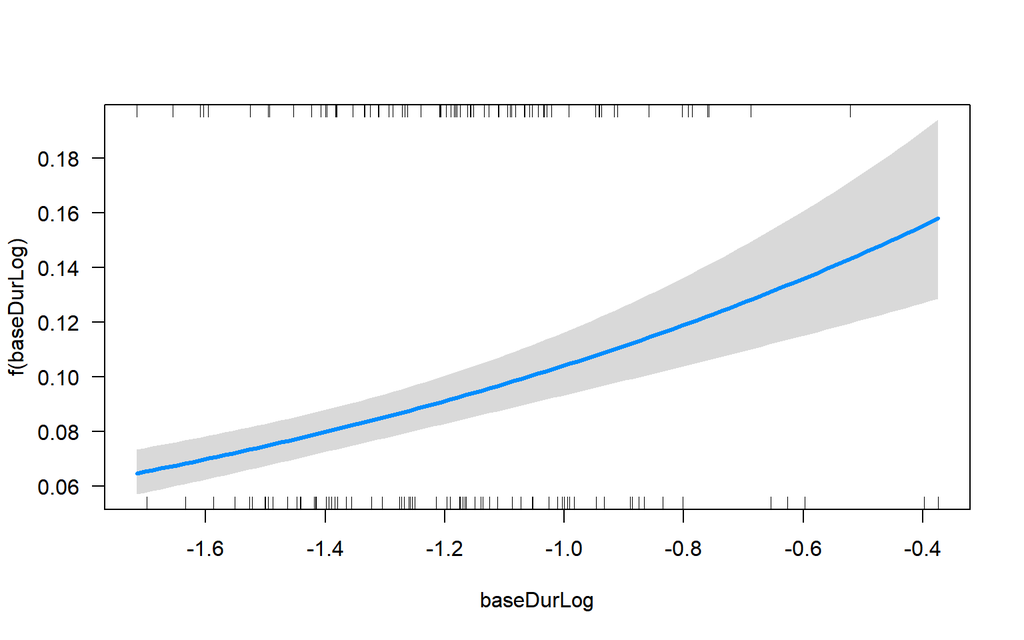

```r
visreg(lm, "baseDurLog", trans = exp)
```

Aber was ist das? Eine Kurve? Obwohl wir über **lineare** Regression sprechen? Ja! Da wir die Y-Achse zurücktransformiert haben, ist der zuvor als linear berechnete Verlauf der Regressionsgeraden nun eine Kurve. Das ändert an der Aussagekraft des Modells nichts.

# 05 Modifikationen

Die Ästhetik von `visreg` genügt sicherlich nicht jedem Anspruch. `visreg` selbst stellt einige (umständliche) Möglichkeiten zur Verfügung, um optische Änderungen vorzunehmen.

## rug

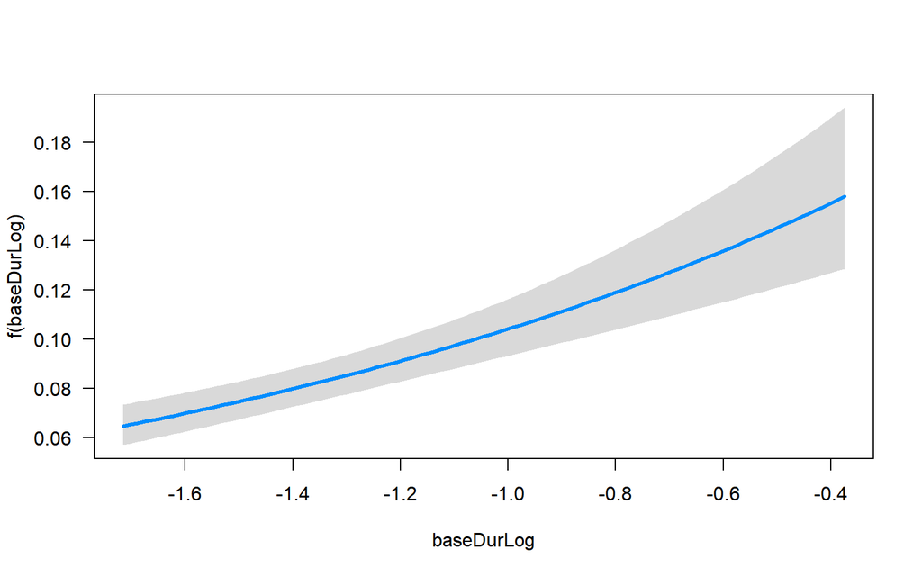

```r
visreg(lm, "baseDurLog", trans = exp, rug = F)
```

## points

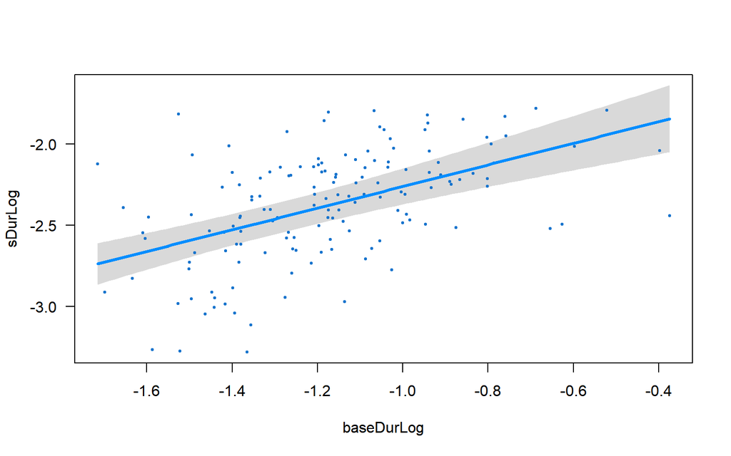

```r
visreg(lm, "baseDurLog", points=list(size=1.5, alpha=0.25, col="dodgerblue3"))
```

## line

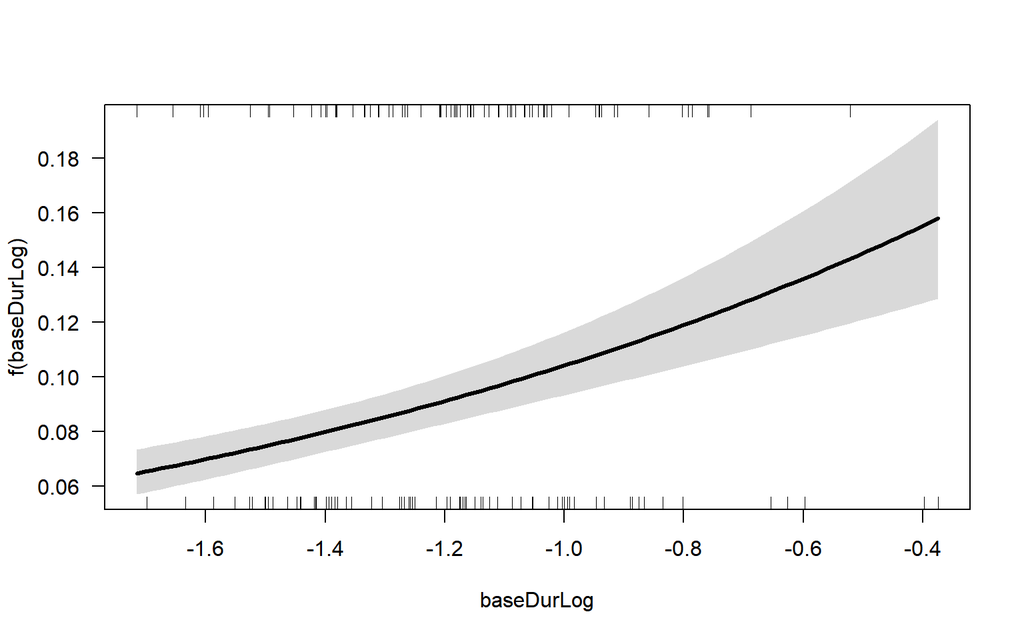

```r
visreg(lm, "baseDurLog", trans = exp, line=list(col="black", size=1))
```

## band

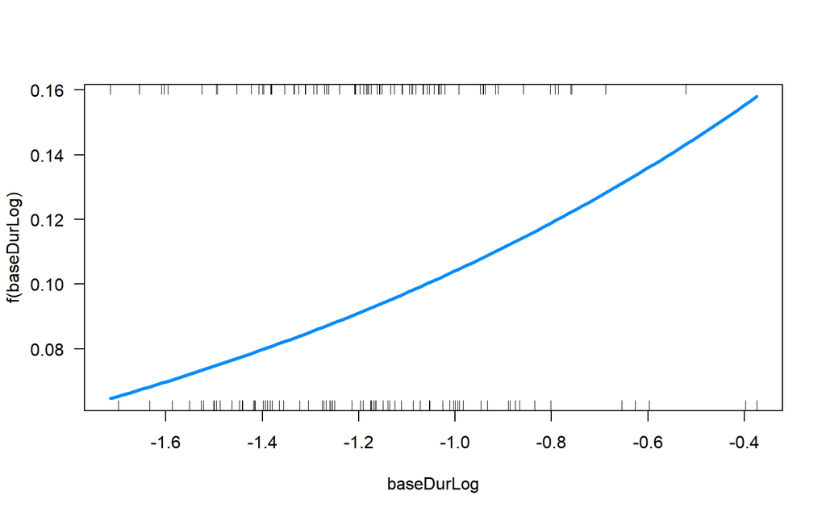

```r
visreg(lm, "baseDurLog", trans = exp, band=F)
```

# 06 visreg meets ggplot2

Dank der großen Beliebtheit von `ggplot2` gibt es zum Glück auch die Möglichkeit, `visreg` mit `ggplot2` zu verbinden. Hierzu muss das `gg` Argument als `TRUE` bestätigt werden:

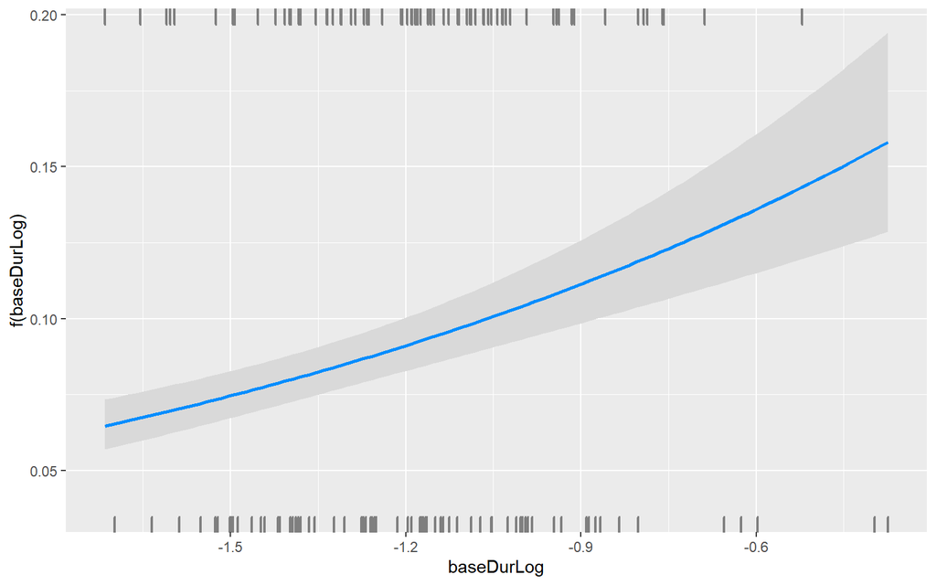

```r
visreg(lm, "baseDurLog", trans = exp, gg=T)
```

Nun können wir all die Möglichkeiten nutzen, die uns ggplot2 zur Verfügung stellt, z.B.:

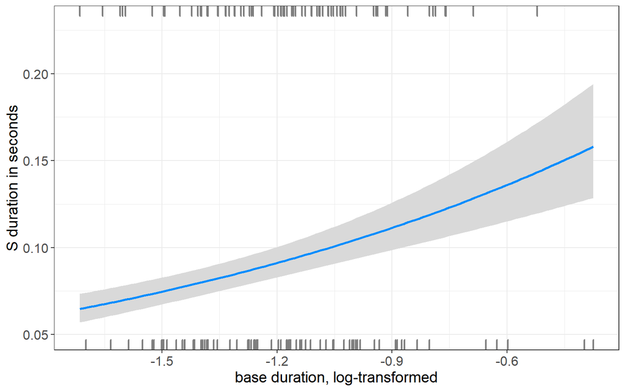

```r
visreg(lm, "baseDurLog", trans = exp, gg=T) +
  theme_bw() +
  theme(axis.text = element_text(size = 12),
        axis.title = element_text(size = 14)
        ) +
  ylab("S duration in seconds") +
  xlab("base duration, log-transformed") +
  scale_y_continuous(limits=c(0.05, 0.23))
```

# 07 Aufgaben

Erstelle die Modelle aus der Sitzung zu Multipler Linearer Regression (siehe unten), um diese dann mit visreg (und ggplot2) darzustellen. Lasse deiner Fantasie dabei freien Lauf!

Aus `data_s`:

- `sDurLog` ~ `bsex` + `age` + `location`
- `sDurLog` ~ `typeOfS` + `pauseBin`
- `sDurLog` ~ `baseDurLog` + `speakingRate`
- `sDurLog` ~ `biphoneProbSumBin` + `folType` + `preC`
- `sDurLog` ~ `bsex` + `age` + `location` + `typeOfS` + `pauseBin` + `baseDurLog` + `speakingRate` + `biphoneProbSumBin` + `folType` + `preC`

Aus `data_a`:

- `height` ~ `bsex` + `hair`
- `height` ~ `hair` + `eyes`
- `height` ~ `bsex` + `hair` + `hair` + `eyes`

Aus `data_v`:

`duration` ~ `vowel` + `structure` + `rate`